# QFT circuit with Qiskit

writer : ericedu1

date : 230628

## 1. Algorithm

QFT, 양자 푸리에 변환은 양자 컴퓨터를 이용해 Fourier 변환을 고전컴퓨터에서보다 좋은 계산 복잡도를 가지도록 시행하는 방법이다. 이에 대한 이론은 다음 페이지에서 확인하도록 한다. 이때, 핵심이 되는 수식은 다음과 같은 Fourier 변환 표현식이다.

$$\begin{align*}&\frac 1 {2^{n/2}}\sum_k[(e^{\frac{2\pi
i}{2^n}})^k]^j\ket k\\&=\frac 1 {2^{n/2}}(\ket 0+e^{2\pi i0.j_n}\ket
1)(\ket 0+e^{2\pi i0.j_{n-1}j_{n}}\ket 1)\cdots(\ket 0+e^{2\pi
i0.j_1\cdots j_{n-1}j_{n}}\ket 1)\end{align*}$$

숙지한 이론을 통해 고안되는 pseudo code는 다음과 같다.

**input** : n (qubit의 수), operator $R_k=R_z(\frac{2\pi}{2^k}),k=1,2,\cdots,n$, $\ket j$.

**output** : fourier transform of $\ket j$ in $\ket k$ basis.

1. Hadamard all state : $\ket {j_k} = \ket 0 + e^{2\pi i j_k/2}\ket 1$
2. Controlled-rotation z gate for target $j_k$, use $j_{k+1}\sim j_n$ as controll :
   $$\begin{align*}
   \ket {j_k} &= \ket 0 + e^{2\pi i j_k/2+2\pi ij_{k+1}/2^2
   +\cdots+2\pi ij_{k+1}/2^{n-k+1}}\ket 1\\&=\ket 0 + e^{2\pi i
   0.j_kj_{k+1}\cdots j_n}\ket 1
   \end{align*}$$
3. SWAP

## 2. By Qiskit

### input.

다음과 같이 초기 설정을 해준다.

```python
from qiskit import *
import numpy as np
from qiskit.circuit.library.standard_gates import *
import math

#configuration

N=7

#circuit setting

qr = QuantumRegister(N,'q')
cr = ClassicalRegister(N, 'c')

qft_circ = QuantumCircuit(qr,cr)
```

### algorithm 1.

모든 상태를 hadamard 해준다. for 문을 이용해 간편하게 처리 가능하다.

```python
#hadamard all qubit
for i in range(N):
    qft_circ.h(qr[i])

qft_circ.barrier()
```

이때 상태는 $\ket {j_k} = \ket 0 + e^{2\pi i j_k/2}\ket 1$ 가 된다.

### algorithm 2.

각 gate 마다 controlled rotation gate를 가해준다.

```python
#link controlled gate
for i in range(N-1):
    print(i)
    t=1
    for j in range(i+1,N):
        qu_li=[qr[j],qr[i]]
        qft_circ.append(RZGate(phi=2*np.pi/(2**(t+1))).control(1),qu_li)
        print(i,'and',j)
        t+=1
    qft_circ.barrier()
```

그 결과는 다음 그림과 같다.

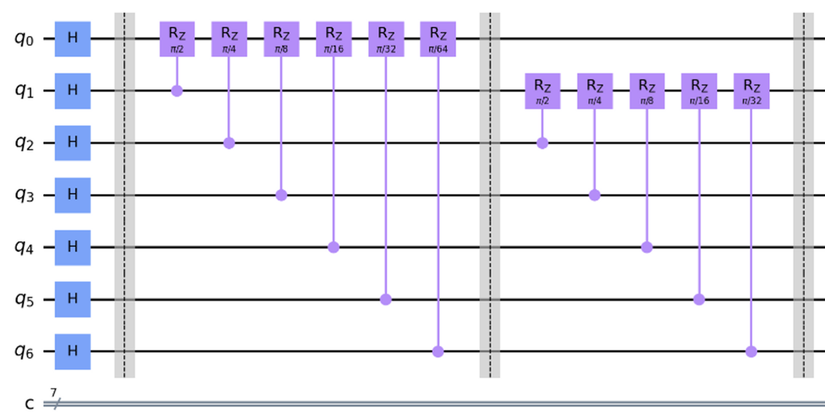

fig1

뒤에 그림이 추가 되지만 자른다.

### algorithm 3.

마지막으로 대칭되는 qubit에 모두 swap gate를 가해준다.

```python
#add swap
for i in range(math.floor(N/2)):
    qft_circ.swap(i,N-i-1)
qft_circ.barrier()
```

이 과정을 거치면 quantum fourier transform의 구성이 마무리 된다. 총 회로는 다음과 같이 얻을 수 있다.

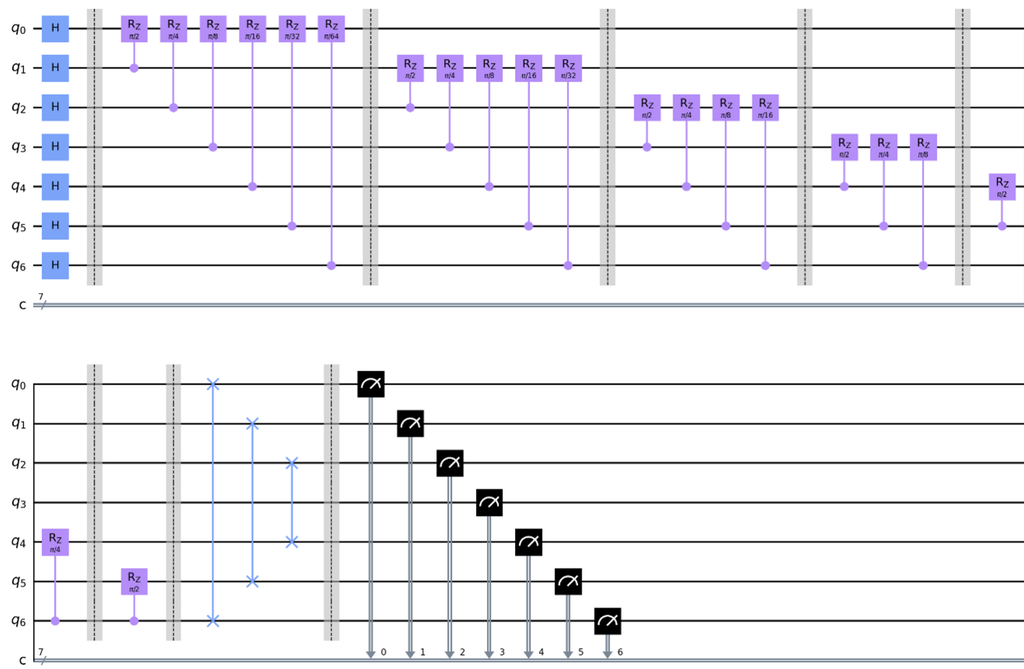

fig2

위의 과정은 7개 qubit에 대해 푸리에 변환을 시행한 결과이다. 이 과정을 거치면, 우리의 construction과 맞아떨어지는 회로 구성이 가능한 것을 알 수 있다.

### 회로 구성 이후 검증

[figure not shown]

```python
qft_circ.measure(qr,cr)
qft_circ.draw(output='mpl', filename='./QFT')

#simulation result check

backend = Aer.get_backend('qasm_simulator')
job = execute(qft_circ, backend, shots=10000000)
result = job.result()
counts = result.get_counts()
print(counts)
```

[output not shown]

reference. Quantum Computation and Quantum Information, Nielson&chuang

To main page